# Exam 1

Westley Cook

2/22/2020

### Question 1

1. The highest emissions are from the country **China** in **2005**.
2. The number of countries that have neither ratified nor approved of the treaty is **9**. *This number includes only countries who indicated acceptance or accession.*
3. The longest number of days between signature and ratification (for a country that has successfully ratified) is **1384** days.
4. The number of ratifying countries whose name ends with “stan” is **7**.
5. In 1960, the country with the highest emissions was **Luxembourg**.
6. The average emissions in 2000 was **4.58** metric tons per capita.

### Question 2

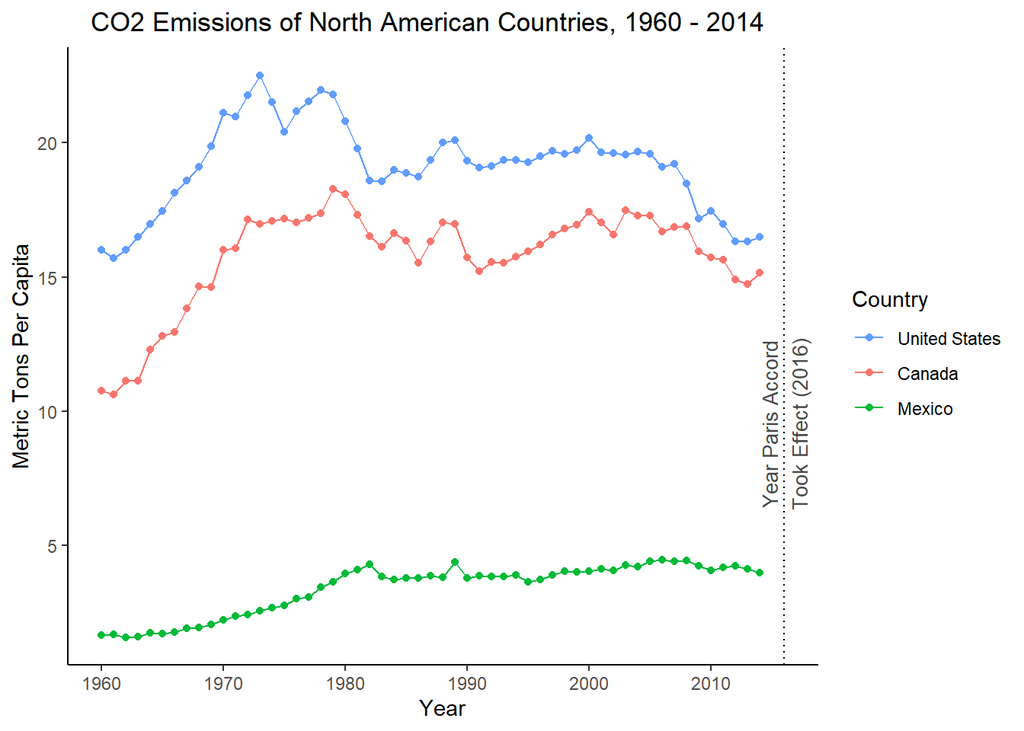

### Question 3

#### Potential Outcomes under the Rubin Causal Framework

The table below shows potential outcomes under the Rubin Causal Framework for countries which ratified the Paris Accord. Suppose we had run an experiment in which we assigned a treatment to all countries whose name begins with a vowel: we gave each of them $1 billion to fight climate change.

(Assigning treatment to countries whose name begins with a vowel may not be a very good random assignment mechanism and may even compromise the results of our experiment, since there are far more countries whose names begin with consonants and ideally we’d have ~50% of countries receiving treatment and the remaining ~50% in the control group; nevertheless, suppose we used it.)

The causal effect we are trying to measure is the difference in emissions for a given country when it receives $1 billion compared to emissions for the same country when it does *not* receive $1 billion. Measuring this causal effect is difficult, because we only know one value per country: as you see in the table (in which unknown values are marked by “?”) emissions for a “treated” country are unknown in the “Control” column and vice versa. However, by making assumptions to “fill in” the unknown values, we can approximate the causal effect.

Potential Outcomes for Paris Experiment on Emissions

For Selected Countries

| Country<sup>1</sup> | Potential Outcomes Emissions Under Control | Potential Outcomes Emissions Under Treatment<sup>2</sup> |
| --- | --- | --- |
| Afghanistan | ? | 19328 |
| Bahamas | 688 | ? |
| Cabo Verde | 448 | ? |
| Ecuador | ? | 247990 |
| Finland | 62989 | ? |
| Gabon | 6160 | ? |
| Haiti | 6683 | ? |
| India | ? | 1523767 |
| Jamaica | 14314 | ? |
| Kazakhstan | 313442 | ? |
| Lao People's Democratic Republic | 8898 | ? |
| Madagascar | 29344 | ? |
| Namibia | 5180 | ? |
| Oman | ? | 20879 |
| Pakistan | 160589 | ? |
| Qatar | 61593 | ? |
| Republic of Korea | 688300 | ? |
| Samoa | 352 | ? |
| Tajikistan | 8184 | ? |
| Uganda | ? | 27560 |
| Vanuatu | 299 | ? |
| Zambia | 14405 | ? |

<sup>*1*</sup> Only one country is shown for each letter of the alphabet (the first one in alphabetical order) <sup>*2*</sup> Treatment is receiving $1 billion to fight climate change, and was given to all countries whose name begins with a vowel